# 数据分析岗位招聘和薪酬水平

## 总述

本次采集有效数据7947条(城市发布量>=100),主要分析围绕数据而展开的相关岗位招聘和薪酬，岗位如：数据分析师、ETL开发工程师、BI工程师、(大)数据开发工程师、数据仓库工程师等。我们将从如下方面分析：

- 01.城市分布：招聘需求主要集中在上海、广州、深圳、北京，分别占市场需求的27%，15%，13%，9%，平均月薪分别为17559元、13635元、14783元、15501元。其余城市均在6%或以下。
- 02.行业分布：招聘主要集中在计算机软件和互联网/电商，分别占29%和11%，平均月薪分别为15475元和14052元。
- 03.公司规模：<1000人企业占68%，平均月薪13751元；1000-5000人占19%，平均月薪15733元。
- 04.公司类型：民企占56%，平均月薪13172元；外企占15%，平均月薪16303元。
- 05.工作经验：5年以下占86%，平均月薪12867元；5-10年占13%，平均月薪23426元。
- 06.学历要求：本科占63%，平均月薪15444元；大专占29%，平均月薪11137元。

## 01.城市分布

[figure not shown]

roadmap

## 02.行业分布

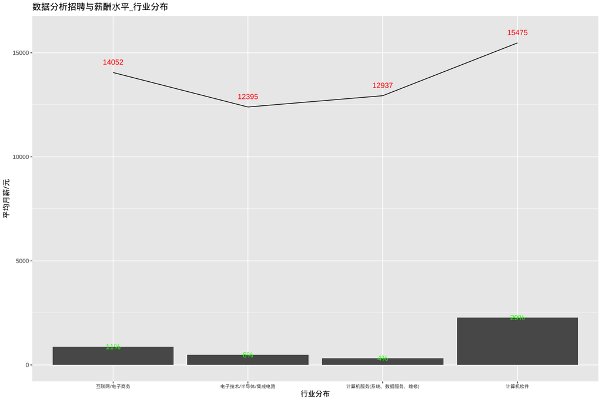

industries

## 03.公司规模

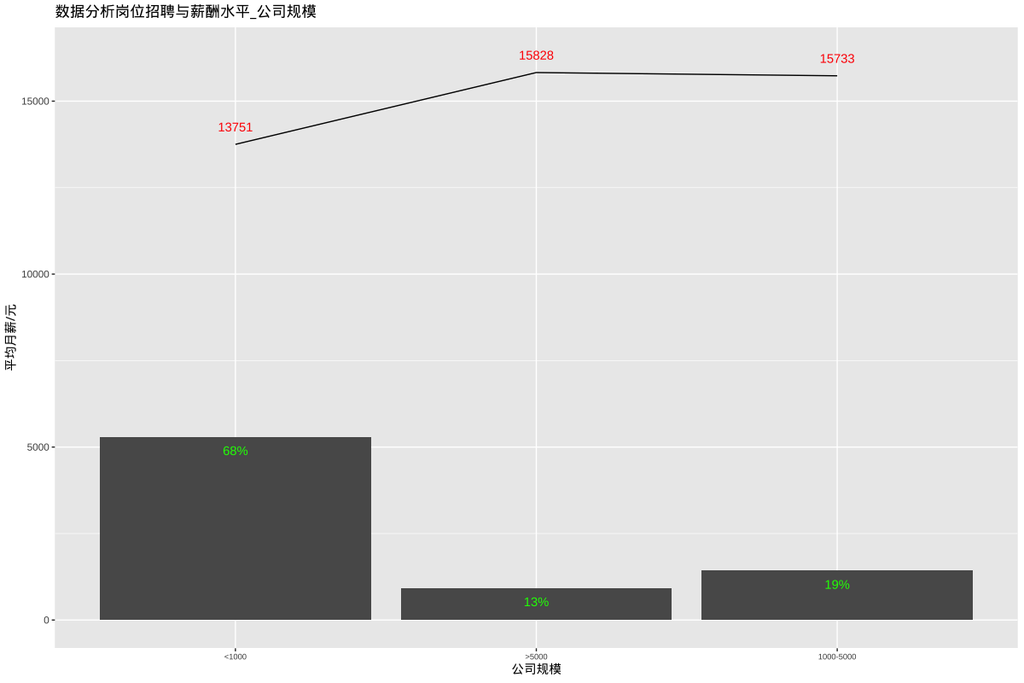

com_size

## 04.公司类型

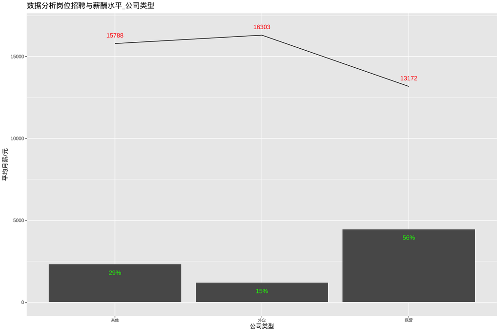

com_type

## 05.工作经验

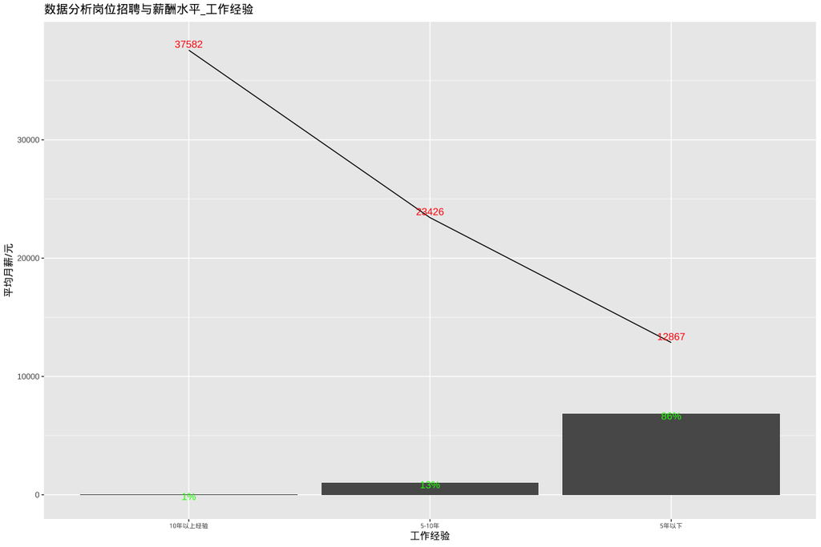

experience

## 06.学历要求

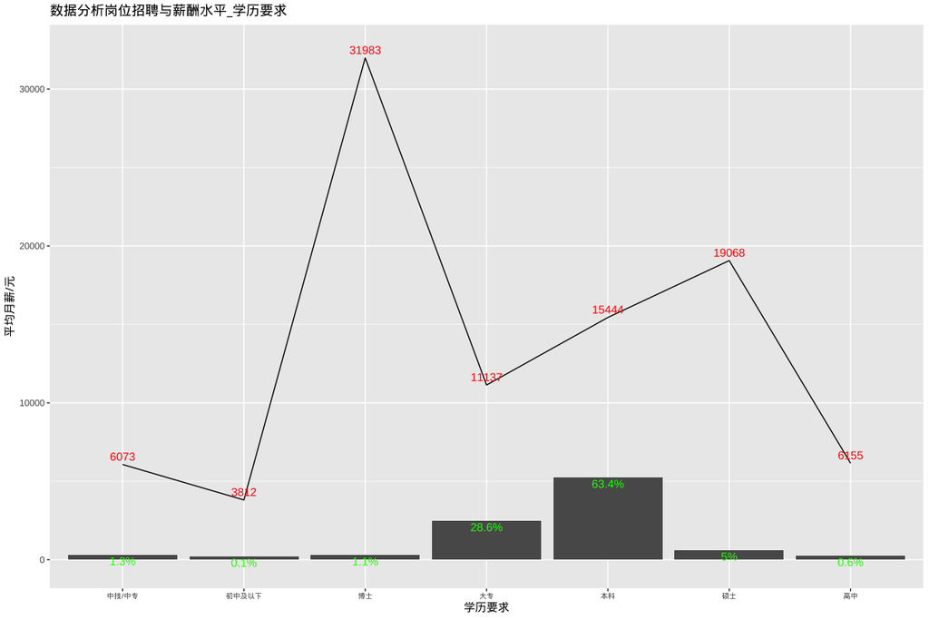

education